# ILab 1

STAT 359 Data Visualization

# Overview

The intent of this lab is to help students determine how well they actually know R.

# Datasets

We will be using the `catsvdogs.txt`, `titanic.txt`, and `mmDATA.txt` datasets for this lab. The datasets can be found on Canvas in **Files** in either the `datasets_master` directory or `getting_started\datasets` directory.

# Tasks

Use the `catsvdogs` dataset to complete the following. Should begin by exploring the data and reading *catsvdogs_codebook.txt* file.

```r
# Import libraries
library(tidyverse)
library(ggthemes)
library(knitr)
library(kableExtra)

# Set theme (don't worry about this now... you'll learn about it later)
theme_set(theme_minimal())

# Import data (don't worry about this now... you'll learn about it later)
catsvdogs_data <- read_delim('catsvdogs.txt', '|')

titanic_data <- read_delim('titanic.txt', '|') %>%
  mutate(class = factor(class),
         adult = factor(adult),
         sex = factor(sex),
         survived = factor(survived))

mm_data <- read_delim('mmDATA.txt', '|')
```

### Cats versus Dogs data

1. Construct a stem plot (histogram or density plot) of the percent of households with pets. What do you observe?

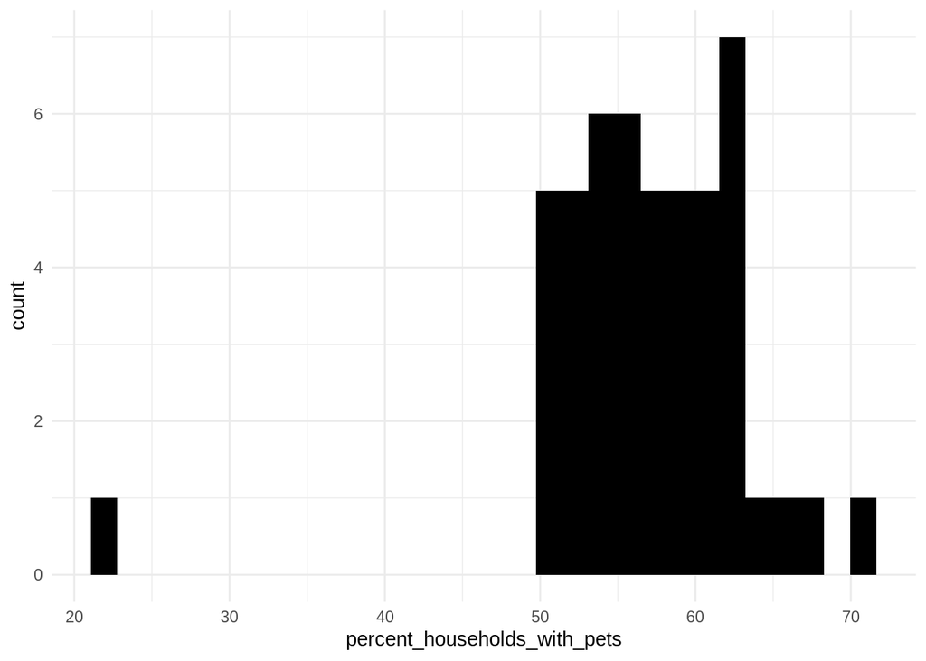

```r
# Response: 50% of more of households in every state, except one (D.C), have pets
ggplot(catsvdogs_data) +
  geom_histogram(aes(percent_households_with_pets), fill = 'black')
```

2. Which of the contiguous states (including DC) has the highest/lowest rate of pet ownership?

```r
# Highest rate of pet ownership
(catsvdogs_data %>%
  mutate('pet_owners' = percent_cat_owners + percent_dog_owners) %>%
  arrange(pet_owners) %>%
  select(location, pet_owners))[nrow(catsvdogs_data),] %>%
  kable() %>%
  kable_styling(full_width = F, position = "left")
```

| location | pet_owners |
| --- | --- |
| Vermont | 87.2 |

```r
# Lowest rate of pet ownership
(catsvdogs_data %>%
    mutate('pet_owners' = percent_cat_owners + percent_dog_owners) %>%
    arrange(pet_owners) %>%
    select(location, pet_owners))[1,] %>%
  kable() %>%
  kable_styling(full_width = F, position = "left")
```

| location | pet_owners |
| --- | --- |
| District of Columbia | 24.7 |

3. Decide on a process to classify each state and DC as preferring cats or dogs. Implement your process and produce a list of states preferring dogs and a list for those that prefer cats.

```r
pet_preference <- catsvdogs_data %>%
  mutate('pet_preference' = ifelse(percent_cat_owners >= percent_dog_owners, 'cats', 'dogs')) %>%
  select(location, pet_preference)

# These states prefer dogs:
filter(pet_preference, pet_preference == 'dogs') %>%
  select(location) %>%
  kable() %>%
  kable_styling(full_width = F, position = "left")
```

| location |
| --- |
| Alabama |
| Arizona |
| Arkansas |
| California |
| Colorado |
| District of Columbia |
| Florida |
| Georgia |
| Idaho |
| Illinois |
| Indiana |
| Iowa |
| Kansas |
| Kentucky |
| Louisiana |
| Maryland |
| Michigan |
| Minnesota |
| Mississippi |
| Missouri |
| Montana |
| Nebraska |
| Nevada |
| New Jersey |
| New Mexico |
| North Carolina |
| North Dakota |
| Ohio |
| Oklahoma |
| Rhode Island |
| South Carolina |
| South Dakota |
| Tennessee |
| Texas |
| Utah |
| Virginia |
| West Virginia |
| Wisconsin |
| Wyoming |

```r
# These states prefer cats:
filter(pet_preference, pet_preference == 'cats') %>%
  select(location) %>%
  kable() %>%
  kable_styling(full_width = F, position = "left")
```

| location |
| --- |
| Connecticut |
| Delaware |
| Maine |
| Massachusetts |
| New Hampshire |
| New York |
| Oregon |
| Pennsylvania |
| Vermont |
| Washington |

4. As part of your exploration of the data, you should have created tables for each of the variables. If not, do so now. Comment on the tables.

### Titanic data

5. Construct a bar graph of the variable class.

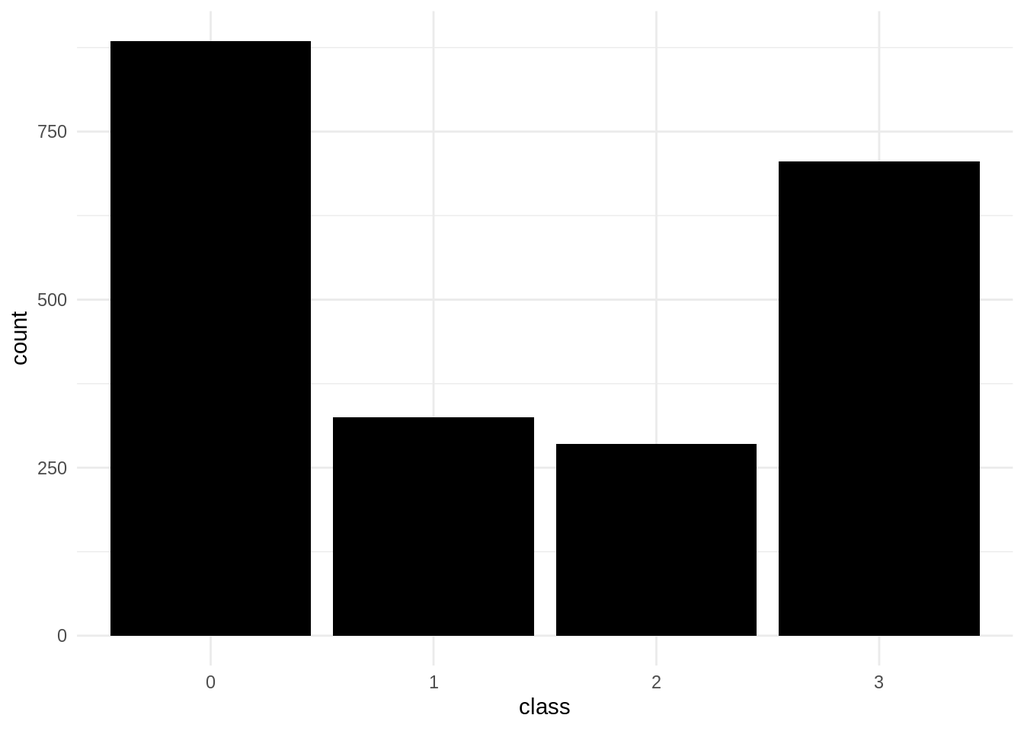

```r
ggplot(titanic_data) +
  geom_bar(aes(class), fill = 'black')
```

6. Build a table of the variable class by the variable survived. What do you observe?

```r
(survived_class_table <- table(titanic_data$class, titanic_data$survived))
```

```
##
##       0   1
##   0 673 212
##   1 122 203
##   2 167 118
##   3 528 178
```

7. Construct a mosaic plot using the package graphics (function mosaicplot). (hint: the input will be the above table built in question 6)

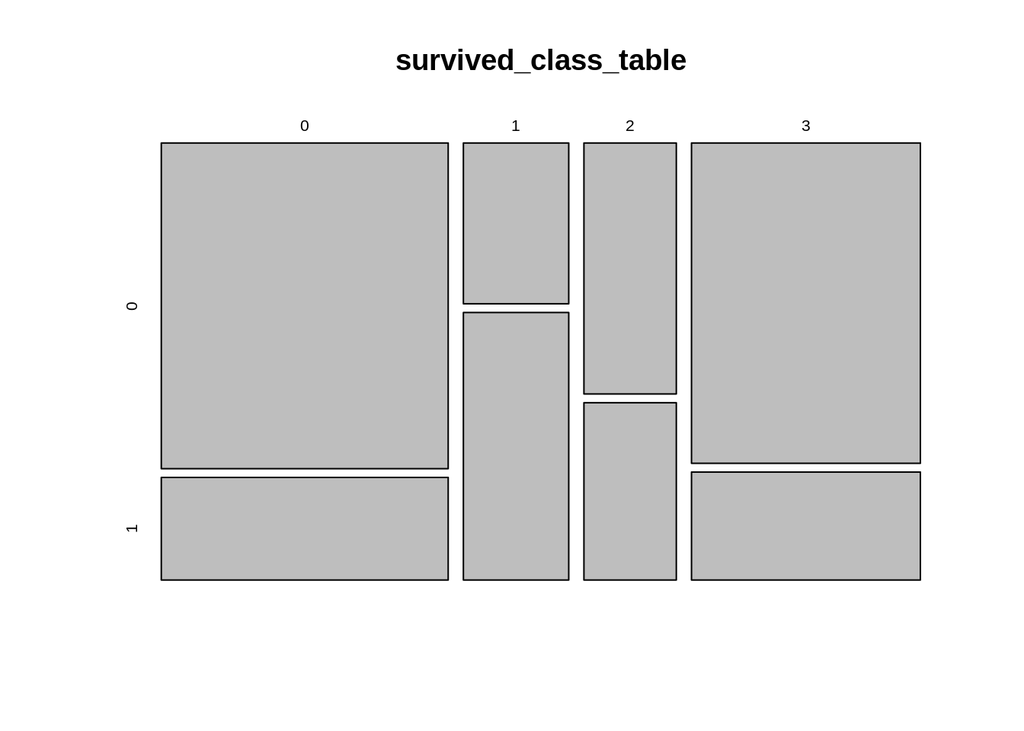

```r
mosaicplot(survived_class_table)
```

8. Explore any other questions you may have.

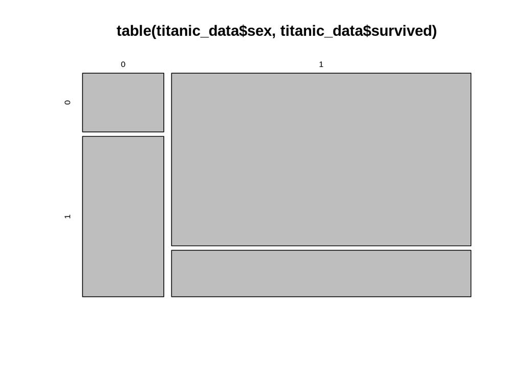

```r
mosaicplot(table(titanic_data$sex, titanic_data$survived))
```

### mmDATA data

9. Construct a bar plot of the colors.

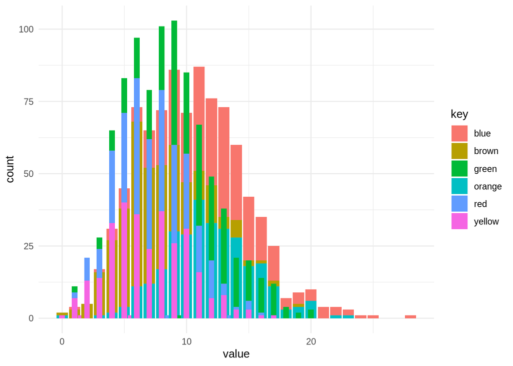

```r
mm_data_for_graph <- gather(select(mm_data, -source))

ggplot(mm_data_for_graph) +
  geom_bar(aes(value, fill = key))
```

10. Plot the proportion of each color across time.

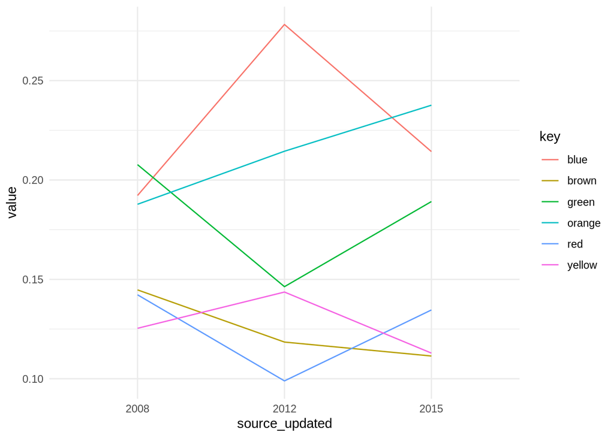

```r
colors_over_time <- mm_data %>%
  mutate('source_updated' = str_sub(source, 3),
         sum = blue + orange + green + yellow + brown + red,
         blue_prop = blue / sum,
         orange_prop = orange / sum,
         green_prop = green / sum,
         yellow_prop = yellow / sum,
         brown_prop = brown / sum,
         red_prop = red / sum) %>%
  select(source_updated, blue_prop, orange_prop, green_prop, yellow_prop, brown_prop, red_prop) %>%
  group_by(source_updated) %>%
  summarise(blue = mean(blue_prop),
            orange = mean(orange_prop),
            green = mean(green_prop),
            yellow = mean(yellow_prop),
            brown = mean(brown_prop),
            red = mean(red_prop))

colors_over_time %>% gather(key, value, blue, orange, green, yellow, brown, red) %>%
  ggplot(aes(x = source_updated, y = value, group = key, color = key)) +
  geom_line()
```